# Amazon Product Co-Purchasing Network Analysis

Author

Megan Millet

## Background & Motivation

### Dataset

This project analyzes the [**Amazon Product Co-Purchasing Network**](https://snap.stanford.edu/data/amazon-meta.html), a dataset collected from the Amazon website in summer 2006. It contains product metadata and review information for 548,552 products spanning four categories: Books, Music CDs, Videos, and DVDs.

| Product Group | Count |
| --- | --- |
| Books | 393,561 |
| Music CDs | 103,144 |
| Videos | 26,132 |
| DVDs | 19,828 |
| **Total** | **548,552** |

Each product entry contains the following fields:

- **Title** — name of the product
- **Salesrank** — Amazon sales ranking at time of collection
- **Similar products** — ASINs of co-purchased products (i.e. customers who bought X also bought Y)
- **Categories** — hierarchical product categorization
- **Reviews** — timestamped entries including customer ID, rating, votes, and helpfulness score

### Network Construction

The co-purchasing relationships form a natural graph structure, where each product is a node and an edge between two products indicates they were frequently bought together. The full network contains 548,552 nodes and 1,788,725 edges. Due to computational constraints, we work with a random sample of 5,000 edges drawn with a fixed seed (`seed=2026`) for reproducibility.

### Motivation

When people shop on Amazon, they often buy related products together. The goal of this analysis is to identify which products appear at the center of these co-purchasing patterns, and whether they are simply popular items or unexpected bridges between different groups of buyers.

*Citation: J. Leskovec, L. Adamic and B. Adamic. The Dynamics of Viral Marketing. ACM Transactions on the Web (ACM TWEB), 1(1), 2007.*

## I. Network Initialization and Random Sampling

### Imports

```python
import networkx as nx
import matplotlib.pyplot as plt
import random
import numpy as np
from sklearn.metrics.pairwise import cosine_similarity
from scipy.stats import pearsonr
```

### Randomly sample 5000 edges from full network

```python
# construct the helper function with fixed seed input
def sample_random_edges(file_path, target_edges, seed):
    random.seed(seed)

    G = nx.Graph()
    current_asin = None
    current_title = None
    edge_count = 0
    p = 0.01

    with open(file_path, "r", encoding="utf-8") as f:
        for line in f:
            if not (line.startswith("ASIN:") or "title:" in line
                    or "group:" in line or "similar:" in line):
                continue

            line = line.strip()

            # parse the relevant data: ASIN, title, group, and similar
            if line.startswith("ASIN:"):
                current_asin = line[5:].strip()
                current_title = None

            elif line.startswith("title:") and current_asin:
                current_title = line[6:].strip()
                G.add_node(current_asin, title=current_title)

            elif line.startswith("group:") and current_asin:
                G.add_node(current_asin, group=line[6:].strip())

            elif line.startswith("similar:") and current_asin:
                parts = line.split()
                for s in parts[2:]:
                    if random.random() < p:
                        G.add_edge(current_asin, s)
                        edge_count += 1
                        if edge_count >= target_edges:
                            print(f"Collected {edge_count} edges.")
                            return G

    return G

# construct the graph via random sampling
#| cache: true
FILE_PATH = "amazon-meta.txt" # stanford SNAP dataset

G_sample = sample_random_edges(
    FILE_PATH,
    target_edges=5000, # 5000 edges for a manageable sample size
    seed=2026 # fixed seed
)
```

```
Collected 5000 edges.
```

### Why is random sampling important? Why use this approach specifically?

The full network contains 1,788,725 edges, making it computationally impossible to analyze it in its entirety on a personal laptop. We use a **Bernoulli sampling** technique to gather edges, by accepting each edge into the graph with probability $p = 0.01$. This parses the file without loading it into memory, and with a fixed seed (=`2026`), we have fully reproducible results.

The main tradeoff with this method is sparsity: gathering only 5,000 edges means many structural relationships are lost, which will be reflected later in the analysis as we observe all-zero similarity scores.

## II. Network Visualization

### Visualize the sampled graph

[figure not shown]

```
Nodes:  157317
Edges:  4998
```

```python
plt.figure(figsize=(4, 4))
pos = nx.random_layout(G_sample, seed=2026)
nx.draw(G_sample, pos, node_size=10, with_labels=False, edge_color="gray", alpha=0.5)
plt.title("Amazon Product Co-Purchasing Network (Sampled)")
plt.show()

print("Nodes: ", len(G_sample.nodes()))
print("Edges: ", len(G_sample.edges()))
```

Since the entire graph contains too many nodes and edges, it is very difficult to visualize any structure.

### Visualize the largest connected component

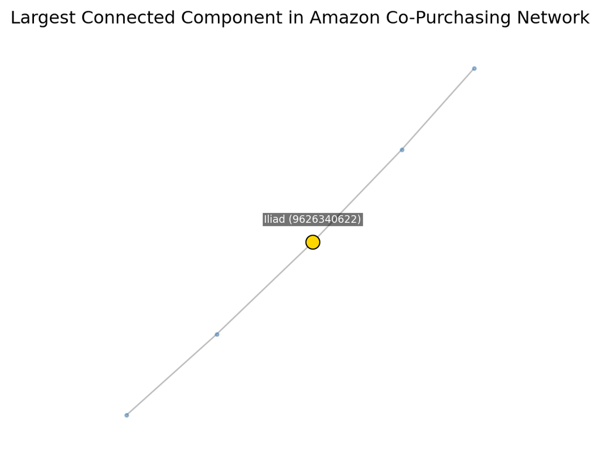

```
Nodes in largest component: 5
Top 5 Nodes in Largest Connected Component by Degree Centrality:
  ASIN: 0451527364 | Score: 0.500000 | Title: N/A | Group: N/A
  ASIN: 0192839519 | Score: 0.500000 | Title: N/A | Group: N/A
  ASIN: 9626340622 | Score: 0.500000 | Title: The Iliad (Classic Literature with Classical Music) | Group: Book
  ASIN: 0881030740 | Score: 0.250000 | Title: Iliad | Group: Book
  ASIN: 0486414353 | Score: 0.250000 | Title: Medieval People | Group: Book
```

```python
# compute largest connected component and make it a subgraph
largest_cc = max(nx.connected_components(G_sample), key=len)
subgraph = G_sample.subgraph(largest_cc)
pos_sub = nx.spring_layout(subgraph, seed=2026, k=0.5)  # renamed from pos

# visualize the largest connected component
plt.figure(figsize=(4, 4))
nx.draw(subgraph, pos_sub, node_size=5, with_labels=False,
        edge_color="gray", node_color="steelblue", alpha=0.5)

# highlight and label only Iliad ASIN 9626340622 in the largest connected component
iliad_asin = "9626340622"
iliad_nodes = [n for n in subgraph.nodes() if n == iliad_asin]

if iliad_nodes:
    nx.draw_networkx_nodes(
        subgraph,
        pos_sub,
        nodelist=iliad_nodes,
        node_color="gold",
        edgecolors="black",
        linewidths=0.8,
        node_size=90,
    )
    ax = plt.gca()
    x, y = pos_sub[iliad_asin]
    ax.annotate(
        "Iliad (9626340622)",
        xy=(x, y),
        xytext=(0, 12),
        textcoords="offset points",
        ha="center",
        va="bottom",
        fontsize=7,
        color="white",
        bbox=dict(facecolor="black", alpha=0.55, edgecolor="none", pad=1.0),
        clip_on=False,
    )

plt.title("Largest Connected Component in Amazon Co-Purchasing Network")
plt.show()

print("Nodes in largest component:", len(subgraph.nodes()))

# identify top 5 most connected nodes in the largest connected component
lcc_degree = nx.degree_centrality(subgraph)
top5_lcc = sorted(lcc_degree.items(), key=lambda x: x[1], reverse=True)[:5]

# print the actual nodes in it
print("Top 5 Nodes in Largest Connected Component by Degree Centrality:")
for asin, score in top5_lcc:
    print(f"  ASIN: {asin} | Score: {score:.6f} | Title: {G_sample.nodes[asin].get('title', 'N/A')} | Group: {G_sample.nodes[asin].get('group', 'N/A')}")
```

All nodes in the largest connected component:

1. *The Iliad (Classic Literature with Classical Music)*, by Homer, 2004 (Book)
2. *Selections from the Canzoniere and Other Works*, by Petrarch, 1999 (Book)
3. *The Odyssey (Signet Classics)*, by Homer, 1999 (Book)
4. *The Iliad*, by Homer, 1999 (Book)
5. *Medieval People*, by Eileen Power, 2000 (Book)

These products can still be accessed through Amazon’s website using the following URL schema: `https://www.amazon.com/dp/{asin}` where `{asin}` is the ASIN of the product. For example, the first product can be found at `https://www.amazon.com/dp/9626340622`.

There are only five nodes in the largest component, as the sampled network is incredibly sparse. As we will see later, *The Iliad (Classic Literature with Classical Music)* book will appear as one of the most central nodes in terms of eigenvector centrality and Katz centrality.

## III. Centrality Analysis

### Degree centrality and identify top 5 products

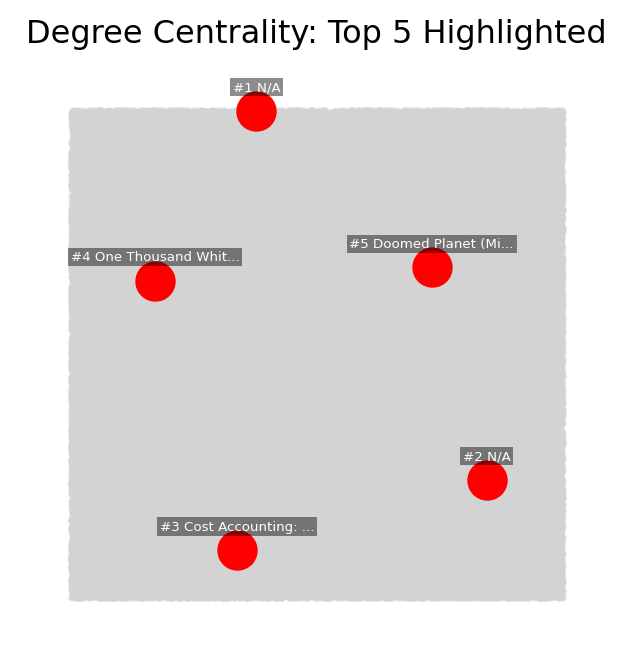

```
Top 5 Products by Degree Centrality:
  ASIN: 1582701148 | Score: 0.00001907 | Title: N/A | Group: N/A
  ASIN: 0323016103 | Score: 0.00001907 | Title: N/A | Group: N/A
  ASIN: 0130649287 | Score: 0.00001907 | Title: Cost Accounting: A Managerial Emphasis, 11th Edition (Student Guide and Review Manual) | Group: Book
  ASIN: 031218008X | Score: 0.00001907 | Title: One Thousand White Women : The Journals Of May Dodd | Group: Book
  ASIN: 088404291X | Score: 0.00001271 | Title: Doomed Planet (Mission Earth, Vol 10) | Group: Book
```

```python
# compute degree centrality
degree_centrality = nx.degree_centrality(G_sample)

# get the top 5 products by degree centrality
top5_degree = sorted(degree_centrality.items(), key=lambda x: x[1], reverse=True)[:5]
top5_nodes = [asin for asin, _ in top5_degree]

# split nodes into two groups for visualization
top5_set = set(top5_nodes)
other_nodes = [n for n in G_sample.nodes() if n not in top5_set]

plt.figure(figsize=(4, 4))

# draw gray nodes first (background)
nx.draw_networkx_nodes(G_sample, pos, nodelist=other_nodes,
                       node_color="lightgray", node_size=2, alpha=0.4)

# draw edges
nx.draw_networkx_edges(G_sample, pos, edge_color="lightgray", alpha=0.3)

# draw top 5 on top (foreground)
nx.draw_networkx_nodes(G_sample, pos, nodelist=top5_nodes,
                       node_color="red", node_size=200, alpha=1.0)

# add labels for the top 5 degree-centrality nodes
deg_labels = {}
for rank, (asin, _) in enumerate(top5_degree, start=1):
    title = G_sample.nodes[asin].get("title", "N/A")
    short_title = title if len(title) <= 20 else title[:17] + "..."
    deg_labels[asin] = f"#{rank} {short_title}"

deg_label_pos = {n: (pos[n][0], pos[n][1] + 0.035) for n in deg_labels}

nx.draw_networkx_labels(
    G_sample,
    deg_label_pos,
    labels=deg_labels,
    font_size=5,
    font_color="white",
    verticalalignment="bottom",
    bbox=dict(facecolor="black", alpha=0.45, edgecolor="none", pad=1.0),
)

plt.title("Degree Centrality: Top 5 Highlighted")
plt.axis("off")
plt.show()

# print top 5 products with their degree centrality, title, and group
print("Top 5 Products by Degree Centrality:")
for asin, centrality in top5_degree:
    print(f"  ASIN: {asin} | Score: {centrality:.8f} | Title: {G_sample.nodes[asin].get('title', 'N/A')} | Group: {G_sample.nodes[asin].get('group', 'N/A')}")
```

### Why are these the top products?

The top five products are as follows:

1. *The Hidden Messages in Water*, by Masaru Emoto, 2004 (Book)
2. *Medical-Surgical Nursing*: Assessment and Management of Clinical Problems, by Sharon M. Lewis, 6th edition, 2003 (Book)
3. *Cost Accounting: A Managerial Emphasis, 11th Edition (Student Guide and Review Manual)*, by Harris, Datar, Foster, 11th edition, 2002 (Book)
4. *One Thousand White Women : The Journals Of May Dodd*, by Jim Fergus, 1998 (Book)
5. *Doomed Planet (Mission Earth, Vol 10)*, by L.Ron Hubbard, 1987 (Book)

Each product page is available at `https://www.amazon.com/dp/{asin}`.

All of the top 5 products are books from a variety of genres. The top products by degree centrality are likely to be popular books that were frequently co-purchased with other books, especially textbooks and bestsellers. Furthermore, 393,561 out of 548,552 products are books in the network, so the top 5 products all being books makes probabilistic sense.

### Eigenvector centrality and identify top 5 products

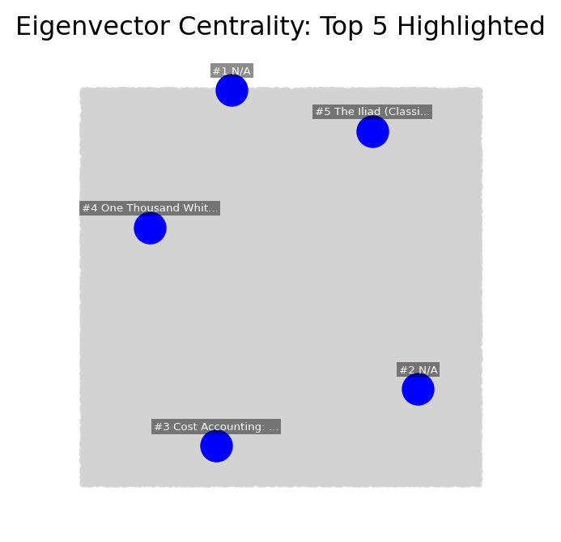

```
Top 5 Products by Eigenvector Centrality:
  ASIN: 1582701148 | Score: 0.3025 | Title: N/A | Group: N/A
  ASIN: 0323016103 | Score: 0.3025 | Title: N/A | Group: N/A
  ASIN: 0130649287 | Score: 0.3025 | Title: Cost Accounting: A Managerial Emphasis, 11th Edition (Student Guide and Review Manual) | Group: Book
  ASIN: 031218008X | Score: 0.3025 | Title: One Thousand White Women : The Journals Of May Dodd | Group: Book
  ASIN: 9626340622 | Score: 0.2754 | Title: The Iliad (Classic Literature with Classical Music) | Group: Book
```

```python
# compute eigenvector centrality
eigenvector_centrality = nx.eigenvector_centrality(G_sample, max_iter=1000)

# get the top 5 products by eigenvector centrality
top5_eigen = sorted(eigenvector_centrality.items(), key=lambda x: x[1], reverse=True)[:5]
top5_nodes = [asin for asin, _ in top5_eigen]

# split nodes into two groups for visualization
top5_set = set(top5_nodes)
other_nodes = [n for n in G_sample.nodes() if n not in top5_set]

plt.figure(figsize=(4, 4))

# draw gray nodes first (background)
nx.draw_networkx_nodes(G_sample, pos, nodelist=other_nodes,
                       node_color="lightgray", node_size=2, alpha=0.4)

# draw edges
nx.draw_networkx_edges(G_sample, pos, edge_color="lightgray", alpha=0.3)

# draw top 5 on top (foreground)
nx.draw_networkx_nodes(G_sample, pos, nodelist=top5_nodes,
                       node_color="blue", node_size=200, alpha=1.0)

# add labels for the top 5 eigenvector-centrality nodes
eigen_labels = {}
for rank, (asin, _) in enumerate(top5_eigen, start=1):
    title = G_sample.nodes[asin].get("title", "N/A")
    short_title = title if len(title) <= 20 else title[:17] + "..."
    eigen_labels[asin] = f"#{rank} {short_title}"

eigen_label_pos = {n: (pos[n][0], pos[n][1] + 0.035) for n in eigen_labels}

nx.draw_networkx_labels(
    G_sample,
    eigen_label_pos,
    labels=eigen_labels,
    font_size=5,
    font_color="white",
    verticalalignment="bottom",
    bbox=dict(facecolor="black", alpha=0.45, edgecolor="none", pad=1.0),
)

plt.title("Eigenvector Centrality: Top 5 Highlighted")
plt.axis("off")
plt.show()

# print top 5 products with their eigenvector centrality, title, and group
print("Top 5 Products by Eigenvector Centrality:")
for asin, centrality in top5_eigen:
    print(f"  ASIN: {asin} | Score: {centrality:.4f} | Title: {G_sample.nodes[asin].get('title', 'N/A')} | Group: {G_sample.nodes[asin].get('group', 'N/A')}")
```

### PageRank and Katz centrality and identify top 5 products

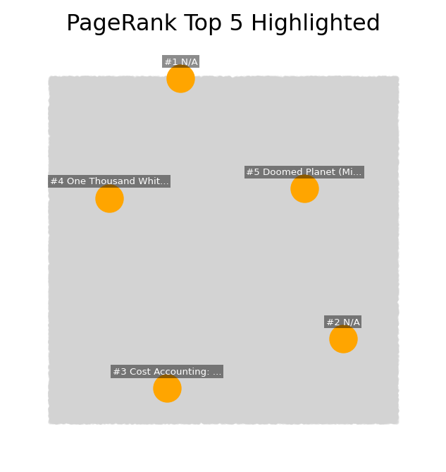

```
Top 5 Products by PageRank:
  ASIN: 1582701148 | Score: 0.00002223 | Title: N/A | Group: N/A
  ASIN: 0323016103 | Score: 0.00002223 | Title: N/A | Group: N/A
  ASIN: 0130649287 | Score: 0.00002223 | Title: Cost Accounting: A Managerial Emphasis, 11th Edition (Student Guide and Review Manual) | Group: Book
  ASIN: 031218008X | Score: 0.00002223 | Title: One Thousand White Women : The Journals Of May Dodd | Group: Book
  ASIN: 088404291X | Score: 0.00001683 | Title: Doomed Planet (Mission Earth, Vol 10) | Group: Book
```

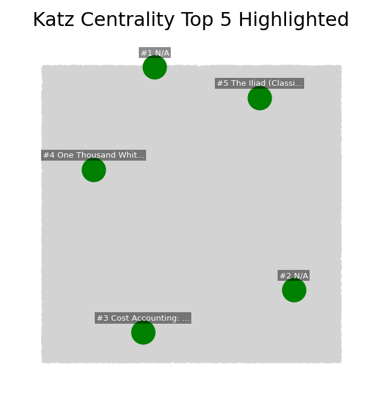

```
Top 5 Products by Katz Centrality:
  ASIN: 1582701148 | Score: 0.00335378 | Title: N/A | Group: N/A
  ASIN: 0323016103 | Score: 0.00335378 | Title: N/A | Group: N/A
  ASIN: 0130649287 | Score: 0.00335378 | Title: Cost Accounting: A Managerial Emphasis, 11th Edition (Student Guide and Review Manual) | Group: Book
  ASIN: 031218008X | Score: 0.00335378 | Title: One Thousand White Women : The Journals Of May Dodd | Group: Book
  ASIN: 9626340622 | Score: 0.00312157 | Title: The Iliad (Classic Literature with Classical Music) | Group: Book
```

```python
# compute pagerank
pagerank = nx.pagerank(G_sample)
top5_pagerank = sorted(pagerank.items(), key=lambda x: x[1], reverse=True)[:5]
top5_pr_nodes = [asin for asin, _ in top5_pagerank]

other_nodes = [n for n in G_sample.nodes() if n not in set(top5_pr_nodes)]

# plot the pagerank on a graph with top 5 highlighted
plt.figure(figsize=(4, 4))
nx.draw_networkx_nodes(G_sample, pos, nodelist=other_nodes,
                       node_color="lightgray", node_size=2, alpha=0.4)
nx.draw_networkx_edges(G_sample, pos, edge_color="lightgray", alpha=0.3)
nx.draw_networkx_nodes(G_sample, pos, nodelist=top5_pr_nodes,
                       node_color="orange", node_size=200, alpha=1.0)

# add labels for the top 5 PageRank nodes
pr_labels = {}
for rank, (asin, _) in enumerate(top5_pagerank, start=1):
    title = G_sample.nodes[asin].get("title", "N/A")
    short_title = title if len(title) <= 20 else title[:17] + "..."
    pr_labels[asin] = f"#{rank} {short_title}"

pr_label_pos = {n: (pos[n][0], pos[n][1] + 0.035) for n in pr_labels}

nx.draw_networkx_labels(
    G_sample,
    pr_label_pos,
    labels=pr_labels,
    font_size=5,
    font_color="white",
    verticalalignment="bottom",
    bbox=dict(facecolor="black", alpha=0.45, edgecolor="none", pad=1.0),
)

plt.title("PageRank Top 5 Highlighted")
plt.axis("off")
plt.show()

# print the top 5 products by pagerank with their scores, titles, and groups
print("Top 5 Products by PageRank:")
for asin, score in top5_pagerank:
    print(f"  ASIN: {asin} | Score: {score:.8f} | Title: {G_sample.nodes[asin].get('title', 'N/A')} | Group: {G_sample.nodes[asin].get('group', 'N/A')}")

# compute katz centrality
katz = nx.katz_centrality(G_sample)
top5_katz = sorted(katz.items(), key=lambda x: x[1], reverse=True)[:5]
top5_katz_nodes = [asin for asin, _ in top5_katz]

other_nodes = [n for n in G_sample.nodes() if n not in set(top5_katz_nodes)]

# plot the katz centrality on a graph with top 5 highlighted
plt.figure(figsize=(4, 4))
nx.draw_networkx_nodes(G_sample, pos, nodelist=other_nodes,
                       node_color="lightgray", node_size=2, alpha=0.4)
nx.draw_networkx_edges(G_sample, pos, edge_color="lightgray", alpha=0.3)
nx.draw_networkx_nodes(G_sample, pos, nodelist=top5_katz_nodes,
                       node_color="green", node_size=200, alpha=1.0)

# add labels for the top 5 Katz-centrality nodes
katz_labels = {}
for rank, (asin, _) in enumerate(top5_katz, start=1):
    title = G_sample.nodes[asin].get("title", "N/A")
    short_title = title if len(title) <= 20 else title[:17] + "..."
    katz_labels[asin] = f"#{rank} {short_title}"

katz_label_pos = {n: (pos[n][0], pos[n][1] + 0.035) for n in katz_labels}

nx.draw_networkx_labels(
    G_sample,
    katz_label_pos,
    labels=katz_labels,
    font_size=5,
    font_color="white",
    verticalalignment="bottom",
    bbox=dict(facecolor="black", alpha=0.45, edgecolor="none", pad=1.0),
)

plt.title("Katz Centrality Top 5 Highlighted")
plt.axis("off")
plt.show()

# print the top 5 products by katz centrality with their scores, titles, and groups
print("Top 5 Products by Katz Centrality:")
for asin, score in top5_katz:
    print(f"  ASIN: {asin} | Score: {score:.8f} | Title: {G_sample.nodes[asin].get('title', 'N/A')} | Group: {G_sample.nodes[asin].get('group', 'N/A')}")
```

### Why are PageRank results aligned with the Degree Centrality results, and Katz results follow Eigenvector Centrality results?

This behavior is expected; it is because of how each measure is mathematically defined.

Katz centrality and eigenvector centrality both reward nodes that are connected to other well-connected nodes, counting not just immediate neighbors but paths of all lengths. Longer paths will contribute exponentially less to the score. This means both measures place *The Iliad* as the 5th product instead of *Doomed Planet*.

Degree centrality and PageRank centrality answer “how many connections does this node have?”, while eigenvector centrality and Katz centrality answer “how well-connected are this node’s neighbors?”

### Shortest Paths Between Top 5 Nodes

To further analyze the structural relationship between the top 5 degree centrality nodes, we can compute the shortest path length between each pair. A short path suggests the products are closely related in the co-purchasing network, while an infinite path (i.e. no path exists) confirms that they are completely disconnected.

```python
# compute shortest paths between top 5 degree centrality nodes
print("Shortest Path Lengths Between Top 5 Degree Centrality Nodes:")
for i, (asin_i, _) in enumerate(top5_degree):
    for j, (asin_j, _) in enumerate(top5_degree):
        if j > i:
            try:
                path_length = nx.shortest_path_length(G_sample, asin_i, asin_j)
                print(f"  #{i+1} vs #{j+1}: {path_length} hops")
            except nx.NetworkXNoPath:
                print(f"  #{i+1} vs #{j+1}: No path exists")
```

```
Shortest Path Lengths Between Top 5 Degree Centrality Nodes:
  #1 vs #2: No path exists
  #1 vs #3: No path exists
  #1 vs #4: No path exists
  #1 vs #5: No path exists
  #2 vs #3: No path exists
  #2 vs #4: No path exists
  #2 vs #5: No path exists
  #3 vs #4: No path exists
  #3 vs #5: No path exists
  #4 vs #5: No path exists
```

As no paths exist between the top 5 degree centrality nodes, we can conclude that they are completely disconnected from each other within the network.

## IV. Similarity Analysis

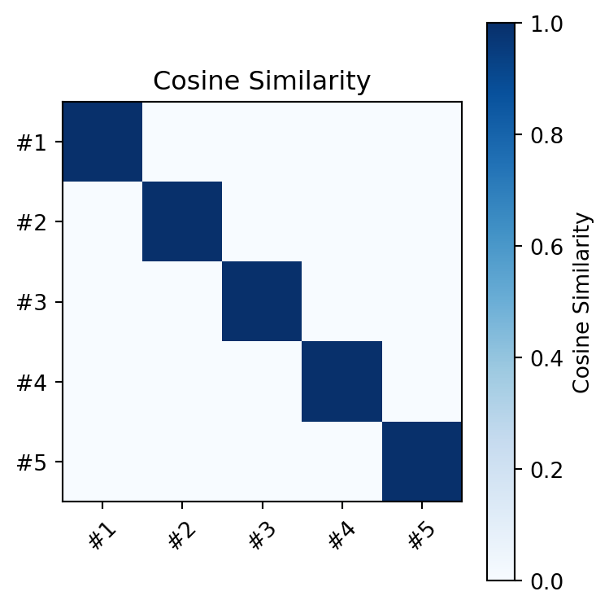

```
Cosine Similarity Matrix for Top 5 Degree Centrality Nodes:
  #1 vs #2: 0.0000
  #1 vs #3: 0.0000
  #1 vs #4: 0.0000
  #1 vs #5: 0.0000
  #2 vs #3: 0.0000
  #2 vs #4: 0.0000
  #2 vs #5: 0.0000
  #3 vs #4: 0.0000
  #3 vs #5: 0.0000
  #4 vs #5: 0.0000
```

```python
# build adjacency vectors for top 5 degree nodes
all_nodes = list(G_sample.nodes())
node_index = {n: i for i, n in enumerate(all_nodes)}

# helper function to get the adjacency vector for a given node
def get_adjacency_vector(node):
    vec = np.zeros(len(all_nodes))
    for neighbor in G_sample.neighbors(node):
        vec[node_index[neighbor]] = 1
    return vec

# collect top 5
top5_vecs = np.array([get_adjacency_vector(n) for n in top5_nodes])
cos_sim = cosine_similarity(top5_vecs)

# display as a heatmap for visualization
fig, ax = plt.subplots(figsize=(4, 4))
im = ax.imshow(cos_sim, cmap="Blues", vmin=0, vmax=1)
ax.set_xticks(range(5))
ax.set_yticks(range(5))
ax.set_xticklabels([f"#{i+1}" for i in range(5)], rotation=45)
ax.set_yticklabels([f"#{i+1}" for i in range(5)])
plt.colorbar(im, ax=ax, label="Cosine Similarity")
plt.title("Cosine Similarity")
plt.tight_layout()
plt.show()

# print the Cosine similarity matrix
print("Cosine Similarity Matrix for Top 5 Degree Centrality Nodes:")
for i, (asin_i, _) in enumerate(top5_degree):
    for j, (asin_j, _) in enumerate(top5_degree):
        if j > i:
            print(f"  #{i+1} vs #{j+1}: {cos_sim[i][j]:.4f}")
```

### Jaccard similarity for top 5 degree nodes

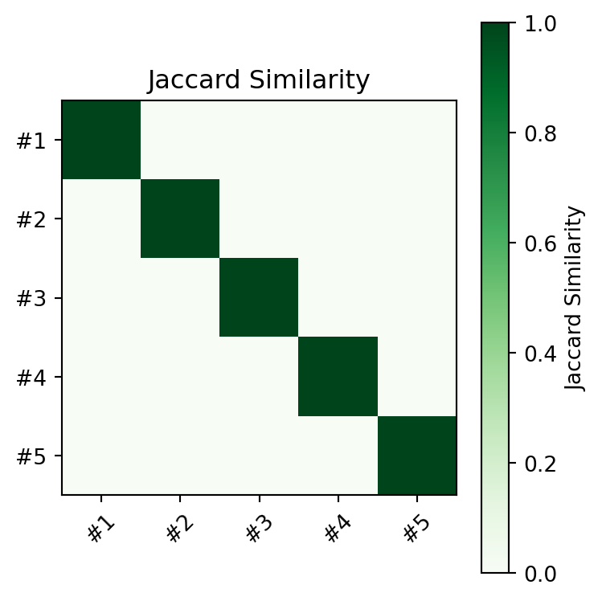

```
Jaccard Similarity Matrix for Top 5 Degree Centrality Nodes:
  #1 vs #2: 0.0000
  #1 vs #3: 0.0000
  #1 vs #4: 0.0000
  #1 vs #5: 0.0000
  #2 vs #3: 0.0000
  #2 vs #4: 0.0000
  #2 vs #5: 0.0000
  #3 vs #4: 0.0000
  #3 vs #5: 0.0000
  #4 vs #5: 0.0000
```

```python
# compute jaccard similarity between top 5 degree nodes
jaccard_matrix = np.zeros((5, 5))
for i, (asin_i, _) in enumerate(top5_degree):
    for j, (asin_j, _) in enumerate(top5_degree):
        if i != j:
            pairs = [(asin_i, asin_j)]
            result = list(nx.jaccard_coefficient(G_sample, pairs))
            jaccard_matrix[i][j] = result[0][2]  # (u, v, score)
        else:
            jaccard_matrix[i][j] = 1.0  # diagonal is self-similarity

# visualize the Jaccard similarity matrix as a heatmap
fig, ax = plt.subplots(figsize=(4, 4))
im = ax.imshow(jaccard_matrix, cmap="Greens", vmin=0, vmax=1)
ax.set_xticks(range(5))
ax.set_yticks(range(5))
ax.set_xticklabels([f"#{i+1}" for i in range(5)], rotation=45)
ax.set_yticklabels([f"#{i+1}" for i in range(5)])
plt.colorbar(im, ax=ax, label="Jaccard Similarity")
plt.title("Jaccard Similarity")
plt.tight_layout()
plt.show()

# print the results
print("Jaccard Similarity Matrix for Top 5 Degree Centrality Nodes:")
for i, (asin_i, _) in enumerate(top5_degree):
    for j, (asin_j, _) in enumerate(top5_degree):
        if j > i:
            print(f"  #{i+1} vs #{j+1}: {jaccard_matrix[i][j]:.4f}")
```

### Pearson’s Correlation Coefficient for the top 5 degree nodes

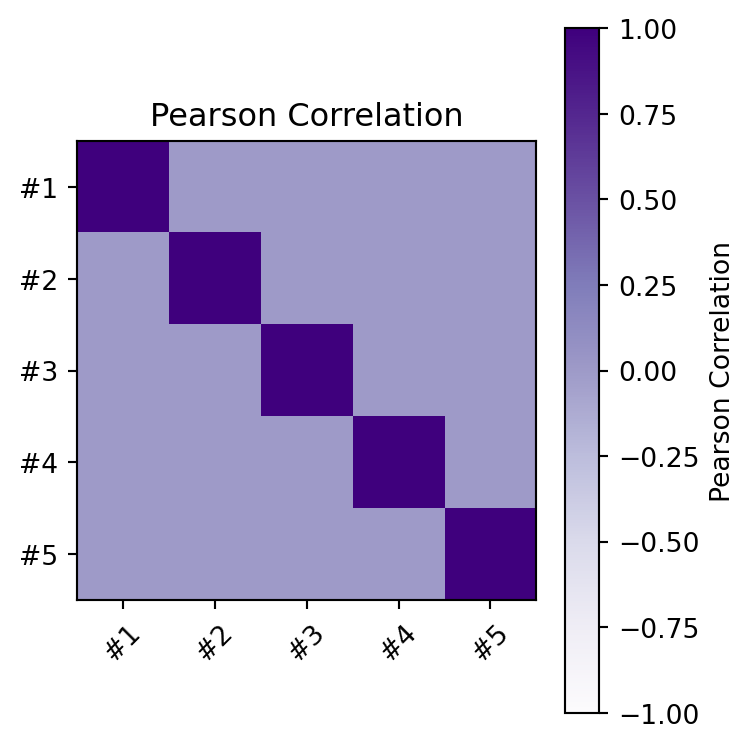

```
Pearson Correlation Matrix for Top 5 Degree Centrality Nodes:
  #1 vs #2: -0.0000
  #1 vs #3: -0.0000
  #1 vs #4: -0.0000
  #1 vs #5: -0.0000
  #2 vs #3: -0.0000
  #2 vs #4: -0.0000
  #2 vs #5: -0.0000
  #3 vs #4: -0.0000
  #3 vs #5: -0.0000
  #4 vs #5: -0.0000
```

```python
# compute pearson correlation between adjacency vectors of top 5 degree nodes
pearson_matrix = np.zeros((5, 5))
for i, (asin_i, _) in enumerate(top5_degree):
    for j, (asin_j, _) in enumerate(top5_degree):
        vec_i = get_adjacency_vector(asin_i)
        vec_j = get_adjacency_vector(asin_j)
        if np.std(vec_i) == 0 or np.std(vec_j) == 0:
            pearson_matrix[i][j] = 0.0
        else:
            pearson_matrix[i][j], _ = pearsonr(vec_i, vec_j)

# visualize as a heatmap
fig, ax = plt.subplots(figsize=(4, 4))
im = ax.imshow(pearson_matrix, cmap="Purples", vmin=-1, vmax=1)
ax.set_xticks(range(5))
ax.set_yticks(range(5))
ax.set_xticklabels([f"#{i+1}" for i in range(5)], rotation=45)
ax.set_yticklabels([f"#{i+1}" for i in range(5)])
plt.colorbar(im, ax=ax, label="Pearson Correlation")
plt.title("Pearson Correlation")
plt.tight_layout()
plt.show()

# print the results
print("Pearson Correlation Matrix for Top 5 Degree Centrality Nodes:")
for i, (asin_i, _) in enumerate(top5_degree):
    for j, (asin_j, _) in enumerate(top5_degree):
        if j > i:
            print(f"  #{i+1} vs #{j+1}: {pearson_matrix[i][j]:.4f}")
```

### Interpreting the similarity results for top 5 degree centrality nodes

All three similarity measures (Cosine, Jaccard, and Pearson) return scores of 0 across every pair of top 5 nodes. This is consistent across all three measures because they all fundamentally ask the same question: “do these nodes share any neighbors?”

Cosine measures the angle between adjacency vectors, Jaccard measures the ratio of shared to total neighbors, and Pearson measures the linear correlation between adjacency vectors; but, if no neighbors are shared, all three scores equal 0.

This result is best explained by the sparsity of our sample. With only 5,000 edges sampled from 1,788,725, the probability of any two nodes sharing a neighbor is extremely low. Rather than indicating that these products are unrelated, it simply reflects the limits of what a 0.28% sample can reveal about shared structure. On the full network, we would expect non-zero similarity scores between at least some of the top products.

## V. Conclusions and Further Considerations

### Summary

Across all four centrality measures, the top products are consistently books, reflecting the dominance of books in the dataset (393,561 out of 548,552 products). Degree centrality and PageRank converge on the same ranking, as do eigenvector centrality and Katz, suggesting two distinct notions of influence in this network: *local connectivity* and *neighborhood quality*.

### Limitations

The most significant limitation of this analysis is the sampling technique implemented. Sampling 5,000 edges from 1,788,725 retains only 0.28% of the full network, which is why similarity measures between top nodes are all 0; the sample is way too sparse to capture shared neighborhoods. A denser sample or the full network would likely reveal more interesting structures.

Additionally, the two ASINs returning `N/A` for title and group were added to the graph solely as co-purchasing targets of other products. Their own product entries were either not reached before sampling terminated, or were never selected as edge sources during the random sampling process, hence why their titles were only stored as `N/A`. Luckily, we could still recover their names by using the ASIN number and inputting that into the Amazon URL.

### Future Work

- **Temporal analysis**: The dataset was collected in 2006. It would be interesting to compare this network structure against a modern Amazon co-purchasing network to see how product influence has shifted over time.
- **Category/group analysis**: Aggregating centrality scores by product group (Book, DVD, Music, Video) could help to identify which product groups tend to occupy more central positions in the co-purchasing network.
- **Product reviews**: Incorporating review data (ratings, helpfulness) could allow us to analyze whether more central products also tend to have higher ratings or more reviews, which could indicate a relationship between influence and customer satisfaction.